# For Oral Exam

Hao Sun

5/6/2023

## Regression Model

```r
# prepare for meeting on 05/03

library(tidyverse)
```

```r
regdat <- readRDS("/Users/sunhao/Documents/GitHub/ChinaAg/From Hao/data/dongbei/regdat_V2.rds") %>%
  mutate(ex_revenue = yield_lag * ex_price + subsidy_lag,
         tcost = yield_lag * cost,
         rcratio = (yield_lag * ex_price + subsidy_lag)/(yield_lag * cost))

regdat <- regdat %>%
  mutate(share_wheat = regdat %>% filter(crop == "wheat") %>% "$"(share) %>%
           matrix(., nrow = 20) %>% # "+"(400) %>% log() %>%
           kronecker(rep(1, 4), .) %>% as.vector()) %>%
  mutate(y2 = log(share/(other + share_wheat)))   # get new y2 since now we combine other and wheat

preddat <- readRDS("/Users/sunhao/Documents/GitHub/ChinaAg/From Hao/data/dongbei/preddat_V2.rds") %>%
  mutate(ex_revenue = yield_lag * ex_price + subsidy_lag,
         tcost = yield_lag * cost,
         rcratio = (yield_lag * ex_price + subsidy_lag)/(yield_lag * cost))

preddat <- preddat %>%
  mutate(share_wheat = preddat %>% filter(crop == "wheat") %>% "$"(share) %>%
           matrix(., nrow = 1) %>% # "+"(400) %>% log() %>%
           kronecker(rep(1, 4), .) %>% as.vector()) %>%
  mutate(y2 = log(share/(other + share_wheat)))

# true share:
share_true <- preddat$share %>% matrix(., nrow = 4) %>% "["(-4,)


# add expected profit for each crop
regdat <- regdat %>%
  mutate(pfex_corn = regdat %>% filter(crop == "corn") %>% "$"(profit_ex) %>%
           matrix(., nrow = 20) %>% # "+"(400) %>% log() %>%
           kronecker(rep(1, 4), .) %>% as.vector(),
         pfex_rice = regdat %>% filter(crop == "rice") %>% "$"(profit_ex) %>%
           matrix(., nrow = 20) %>% # "+"(400) %>% log() %>%
           kronecker(rep(1, 4), .) %>% as.vector(),
         pfex_soy = regdat %>% filter(crop == "soybean") %>% "$"(profit_ex) %>%
           matrix(., nrow = 20) %>% # "+"(400) %>% log() %>%
           kronecker(rep(1, 4), .) %>% as.vector(),
         pfex_wheat = regdat %>% filter(crop == "wheat") %>% "$"(profit_ex) %>%
           matrix(., nrow = 20) %>% # "+"(400) %>% log() %>%
           kronecker(rep(1, 4), .) %>% as.vector()
  )


# same for the predicted data
preddat <- preddat %>%
  mutate(pfex_corn = preddat %>% filter(crop == "corn") %>% "$"(profit_ex) %>%
           matrix(., nrow = 1) %>% # "+"(400) %>% log() %>%
           kronecker(rep(1, 4), .) %>% as.vector(),
         pfex_rice = preddat %>% filter(crop == "rice") %>% "$"(profit_ex) %>%
           matrix(., nrow = 1) %>% # "+"(400) %>% log() %>%
           kronecker(rep(1, 4), .) %>% as.vector(),
         pfex_soy = preddat %>% filter(crop == "soybean") %>% "$"(profit_ex) %>%
           matrix(., nrow = 1) %>% #"+"(400) %>% log() %>%
           kronecker(rep(1, 4), .) %>% as.vector(),
         pfex_wheat = preddat %>% filter(crop == "wheat") %>% "$"(profit_ex) %>%
           matrix(., nrow = 1) %>% #"+"(400) %>% log() %>%
           kronecker(rep(1, 4), .) %>% as.vector()
  )

regdat <- regdat %>% filter(!region %in% c("Shandong", "Hebei"))
preddat <- preddat %>% filter(!region %in% c("Shandong", "Hebei"))

regdat_V2 <- rbind(regdat, preddat)
```

```r
regdat_V2$policy <- as.numeric(regdat_V2$subsidy > 0)

# model 1:
lm_corn_pf <- lm(y2 ~ 0 + region + pfex_corn + pfex_rice + pfex_soy + policy,
                 data = regdat_V2 %>% filter(crop == "corn"))

lm_rice_pf <- lm(y2 ~  0 + region + pfex_corn + pfex_rice + pfex_soy + policy,
                 data = regdat_V2 %>% filter(crop == "rice"))

lm_soy_pf <- lm(y2 ~  0 + region + pfex_corn + pfex_rice + pfex_soy + policy,
                data = regdat_V2 %>% filter(crop == "soybean"))

summary(lm_corn_pf)
```

```
##
## Call:
## lm(formula = y2 ~ 0 + region + pfex_corn + pfex_rice + pfex_soy +
##     policy, data = regdat_V2 %>% filter(crop == "corn"))
##
## Residuals:
##      Min       1Q   Median       3Q      Max
## -1.09143 -0.17765  0.02607  0.18781  0.87553
##
## Coefficients:
##                      Estimate Std. Error t value Pr(>|t|)
## regionNeimenggu    -1.0679626  0.2019003  -5.290 1.14e-06 ***
## regionJilin         0.6677898  0.1735128   3.849 0.000246 ***
## regionLiaoning      0.0631872  0.1779759   0.355 0.723549
## regionHeilongjiang  0.3754288  0.1836143   2.045 0.044351 *
## pfex_corn           0.0010011  0.0004545   2.203 0.030645 *
## pfex_rice           0.0007111  0.0004147   1.715 0.090446 .
## pfex_soy           -0.0007662  0.0004441  -1.725 0.088557 .
## policy              0.8536749  0.1027837   8.306 2.86e-12 ***
## ---
## Signif. codes:  0 '***' 0.001 '**' 0.01 '*' 0.05 '.' 0.1 ' ' 1
##
## Residual standard error: 0.3802 on 76 degrees of freedom
## Multiple R-squared:  0.8758, Adjusted R-squared:  0.8627
## F-statistic: 66.96 on 8 and 76 DF,  p-value: < 2.2e-16
```

```r
summary(lm_rice_pf)
```

```
##
## Call:
## lm(formula = y2 ~ 0 + region + pfex_corn + pfex_rice + pfex_soy +
##     policy, data = regdat_V2 %>% filter(crop == "rice"))
##
## Residuals:
##     Min      1Q  Median      3Q     Max
## -1.2055 -0.1695  0.0338  0.1875  0.8634
##
## Coefficients:
##                      Estimate Std. Error t value Pr(>|t|)
## regionNeimenggu    -4.1452559  0.2018128 -20.540  < 2e-16 ***
## regionJilin        -0.6830094  0.1734376  -3.938 0.000181 ***
## regionLiaoning     -1.0563954  0.1778988  -5.938 8.09e-08 ***
## regionHeilongjiang  0.1216182  0.1835347   0.663 0.509563
## pfex_corn           0.0008242  0.0004543   1.814 0.073570 .
## pfex_rice           0.0003839  0.0004145   0.926 0.357271
## pfex_soy           -0.0005552  0.0004439  -1.251 0.214947
## policy              0.6213919  0.1027391   6.048 5.11e-08 ***
## ---
## Signif. codes:  0 '***' 0.001 '**' 0.01 '*' 0.05 '.' 0.1 ' ' 1
##
## Residual standard error: 0.38 on 76 degrees of freedom
## Multiple R-squared:  0.9646, Adjusted R-squared:  0.9609
## F-statistic:   259 on 8 and 76 DF,  p-value: < 2.2e-16
```

```r
summary(lm_soy_pf)
```

```
##
## Call:
## lm(formula = y2 ~ 0 + region + pfex_corn + pfex_rice + pfex_soy +
##     policy, data = regdat_V2 %>% filter(crop == "soybean"))
##
## Residuals:
##      Min       1Q   Median       3Q      Max
## -0.94686 -0.24926  0.02212  0.23812  0.96421
##
## Coefficients:
##                      Estimate Std. Error t value Pr(>|t|)
## regionNeimenggu    -1.5115259  0.2003759  -7.543 8.20e-11 ***
## regionJilin        -1.1040573  0.1756131  -6.287 1.87e-08 ***
## regionLiaoning     -2.0779904  0.1806994 -11.500  < 2e-16 ***
## regionHeilongjiang  0.8652645  0.1841471   4.699 1.14e-05 ***
## pfex_corn          -0.0002800  0.0004405  -0.636    0.527
## pfex_rice          -0.0001724  0.0004201  -0.410    0.683
## pfex_soy            0.0008592  0.0004295   2.001    0.049 *
## policy              0.0282445  0.0966764   0.292    0.771
## ---
## Signif. codes:  0 '***' 0.001 '**' 0.01 '*' 0.05 '.' 0.1 ' ' 1
##
## Residual standard error: 0.3862 on 76 degrees of freedom
## Multiple R-squared:  0.9413, Adjusted R-squared:  0.9351
## F-statistic: 152.4 on 8 and 76 DF,  p-value: < 2.2e-16
```

## Prediction for 2022 to 2024

### Construct the prediction data

We need to predict the expected profit for `corn`, `rice`, and `soybean`. To calculate the expected profict, we define

$$\text{Ex Profit}_t = \text{Pred Yield}_{t} * (\text{Ex Price}_t - \text{Cost}_t) + \text{Subsidy}_{t-1}$$
The predicted yield is the average of previous three years’ yield values.

Therefore, we need to predict $\text{Yield}$, $\text{Ex Price}$, $\text{Cost}$ and $\text{Subsidy}$.

Step 1: genetate region, crop, and year

```r
prednew <- data.frame(region = rep(rep(c("Neimenggu", "Jilin",
                                     "Liaoning", "Heilongjiang"), each = 4), 3),
                      crop = rep(c("corn", "rice", "soybean", "wheat"), 12),
                      year = rep(2022:2024, each = 16))
```

Step 2: Predict Subsidy

We consider fix the subsidy for corn and rice but consider four possible change for subsidy of soybean:

- Same subsidy
- Increase 10%
- Increase 20%
- Increase 30%

```r
prednew$subsidy <- rep(preddat$subsidy, 3)  # same subsidy

prednew$subsidy01 <- prednew$subsidy  # increase 10%
prednew$subsidy01[prednew$crop == "soybean"] <- prednew$subsidy[prednew$crop == "soybean"] * 1.1

prednew$subsidy02 <- prednew$subsidy  # increase 20%
prednew$subsidy02[prednew$crop == "soybean"] <- prednew$subsidy[prednew$crop == "soybean"] * 1.2

prednew$subsidy03 <- prednew$subsidy  # increase 30%
prednew$subsidy03[prednew$crop == "soybean"] <- prednew$subsidy[prednew$crop == "soybean"] * 1.3
```

Step 3: Construct subsidy lag

```r
prednew$subsidy_lag <- prednew$subsidy
prednew$subsidy01_lag <- prednew$subsidy
prednew$subsidy02_lag <- prednew$subsidy
prednew$subsidy03_lag <- prednew$subsidy

prednew$subsidy01_lag[prednew$year > 2022] <- prednew$subsidy01[prednew$year > 2022]
prednew$subsidy02_lag[prednew$year > 2022] <- prednew$subsidy02[prednew$year > 2022]
prednew$subsidy03_lag[prednew$year > 2022] <- prednew$subsidy03[prednew$year > 2022]
```

Step 4: Impute the Yield and Yield_lag

```r
prednew$yield <- 0

for(i in c("corn", "rice", "soybean", "wheat"))
{
  lm_yield <- lm(yield ~ 0 + region + year, data = regdat_V2 %>% filter(crop == i))
  pred_yield <- predict(lm_yield, newdata = prednew %>% filter(crop == i))
  prednew$yield[prednew$crop == i] <- pred_yield
}

tmpdat <- rbind(regdat_V2 %>% select(region, crop, year, yield),
                prednew %>% select(region, crop, year, yield)) %>%
  arrange(region, crop, year)

tmpdat$yield_lag <- get_lag(tmpdat, "yield", 3, weight = c(0.34, 0.33, 0.33))

prednew$yield_lag <- tmpdat %>% filter(year > 2021) %>% arrange(year, region) %>%
  "$"(yield_lag)
```

Step 5: Impute Cost and Expected Price

```r
prednew$ex_price <- 0
prednew$cost <- 0

for(i in c("corn", "rice", "soybean", "wheat"))
{
  lm_exprice <- lm(ex_price ~ 0 + region + year, data = regdat_V2 %>% filter(crop == i))
  pred_exprice <- predict(lm_exprice, newdata = prednew %>% filter(crop == i))
  prednew$ex_price[prednew$crop == i] <- pred_exprice

  lm_cost <- lm(cost ~ 0 + region + year, data = regdat_V2 %>% filter(crop == i))
  pred_cost <- predict(lm_cost, newdata = prednew %>% filter(crop == i))
  prednew$cost[prednew$crop == i] <- pred_cost
}
```

Step 6: Calculate the Expected Profit

```r
preddat_newsame <- prednew %>%
  mutate(profit_ex = yield_lag * (ex_price - cost) + subsidy_lag) %>%
  arrange(region, crop, year)

preddat_new01 <- prednew %>%
  mutate(profit_ex = yield_lag * (ex_price - cost) + subsidy01_lag) %>%
  arrange(region, crop, year)

preddat_new02 <- prednew %>%
  mutate(profit_ex = yield_lag * (ex_price - cost) + subsidy02_lag) %>%
  arrange(region, crop, year)

preddat_new03 <- prednew %>%
  mutate(profit_ex = yield_lag * (ex_price - cost) + subsidy03_lag) %>%
  arrange(region, crop, year)
```

### Prediction

Step 1: Construct covariates

```r
preddat_newsame <- preddat_newsame %>%
    mutate(pfex_corn = preddat_newsame %>% filter(crop == "corn") %>% "$"(profit_ex) %>%
           matrix(., nrow = 3) %>% kronecker(rep(1, 4), .) %>% as.vector(),
         pfex_rice = preddat_newsame %>% filter(crop == "rice") %>% "$"(profit_ex) %>%
           matrix(., nrow = 3) %>% kronecker(rep(1, 4), .) %>% as.vector(),
         pfex_soy = preddat_newsame %>% filter(crop == "soybean") %>% "$"(profit_ex) %>%
           matrix(., nrow = 3) %>% kronecker(rep(1, 4), .) %>% as.vector(),
         pfex_wheat = preddat_newsame %>% filter(crop == "wheat") %>% "$"(profit_ex) %>%
           matrix(., nrow = 3) %>% kronecker(rep(1, 4), .) %>% as.vector(),
         policy = 1
  )

preddat_new01 <- preddat_new01%>%
    mutate(pfex_corn = preddat_new01 %>% filter(crop == "corn") %>% "$"(profit_ex) %>%
           matrix(., nrow = 3) %>% kronecker(rep(1, 4), .) %>% as.vector(),
         pfex_rice = preddat_new01 %>% filter(crop == "rice") %>% "$"(profit_ex) %>%
           matrix(., nrow = 3) %>% kronecker(rep(1, 4), .) %>% as.vector(),
         pfex_soy = preddat_new01 %>% filter(crop == "soybean") %>% "$"(profit_ex) %>%
           matrix(., nrow = 3) %>% kronecker(rep(1, 4), .) %>% as.vector(),
         pfex_wheat = preddat_new01 %>% filter(crop == "wheat") %>% "$"(profit_ex) %>%
           matrix(., nrow = 3) %>% kronecker(rep(1, 4), .) %>% as.vector(),
         policy = 1
  )

preddat_new02 <- preddat_new02 %>%
    mutate(pfex_corn = preddat_new02 %>% filter(crop == "corn") %>% "$"(profit_ex) %>%
           matrix(., nrow = 3) %>% kronecker(rep(1, 4), .) %>% as.vector(),
         pfex_rice = preddat_new02 %>% filter(crop == "rice") %>% "$"(profit_ex) %>%
           matrix(., nrow = 3) %>% kronecker(rep(1, 4), .) %>% as.vector(),
         pfex_soy = preddat_new02 %>% filter(crop == "soybean") %>% "$"(profit_ex) %>%
           matrix(., nrow = 3) %>% kronecker(rep(1, 4), .) %>% as.vector(),
         pfex_wheat = preddat_new02 %>% filter(crop == "wheat") %>% "$"(profit_ex) %>%
           matrix(., nrow = 3) %>% kronecker(rep(1, 4), .) %>% as.vector(),
         policy = 1
  )

preddat_new03 <- preddat_new03 %>%
    mutate(pfex_corn = preddat_new03 %>% filter(crop == "corn") %>% "$"(profit_ex) %>%
           matrix(., nrow = 3) %>% kronecker(rep(1, 4), .) %>% as.vector(),
         pfex_rice = preddat_new03 %>% filter(crop == "rice") %>% "$"(profit_ex) %>%
           matrix(., nrow = 3) %>% kronecker(rep(1, 4), .) %>% as.vector(),
         pfex_soy = preddat_new03 %>% filter(crop == "soybean") %>% "$"(profit_ex) %>%
           matrix(., nrow = 3) %>% kronecker(rep(1, 4), .) %>% as.vector(),
         pfex_wheat = preddat_new03 %>% filter(crop == "wheat") %>% "$"(profit_ex) %>%
           matrix(., nrow = 3) %>% kronecker(rep(1, 4), .) %>% as.vector(),
         policy = 1
  )
```

Step 2: Predict Y2

```r
preddat_newsame$Y2 <- 0
preddat_new01$Y2 <- 0
preddat_new02$Y2 <- 0
preddat_new03$Y2 <- 0

for(i in c("corn", "rice", "soybean"))
{
  if(i == "corn")
  {
    lmtmp = lm_corn_pf
  } else if(i == "rice")
  {
    lmtmp = lm_rice_pf
  } else if(i == "soybean")
  {
    lmtmp = lm_soy_pf
  }
  preddat_newsame$Y2[preddat_newsame$crop == i] <-
    predict(lmtmp, newdata = preddat_newsame %>% filter(crop == i))
  preddat_new01$Y2[preddat_new01$crop == i] <-
    predict(lmtmp, newdata = preddat_new01 %>% filter(crop == i))
  preddat_new02$Y2[preddat_new02$crop == i] <-
    predict(lmtmp, newdata = preddat_new02 %>% filter(crop == i))
  preddat_new03$Y2[preddat_new03$crop == i] <-
    predict(lmtmp, newdata = preddat_new03 %>% filter(crop == i))
}
```

Step 3: Predict share

$$Y_2 = \log(\text{Share}/\text{Share}_{other})$$

```r
preddat_newsame$share <- 0
preddat_new01$share <- 0
preddat_new02$share <- 0
preddat_new03$share <- 0

for(i in 2022:2024)
{
  # fix
  tmp_newsame <- preddat_newsame %>% filter(year == i, crop != "wheat") %>%
    "$"(Y2) %>%matrix(., ncol = 3, byrow = T)
  other_newsame <- 1/(rowSums(exp(tmp_newsame)) + 1)
  share_newsame <- sweep(exp(tmp_newsame), MARGIN = 1, FUN = "*", STATS = other_newsame)
  preddat_newsame$share[preddat_newsame$year == i &
                          preddat_newsame$crop != "wheat"] <-
    t(share_newsame) %>% as.numeric()

  # soybean increase 10%
  tmp_new01 <- preddat_new01 %>% filter(year == i, crop != "wheat") %>%
    "$"(Y2) %>%matrix(., ncol = 3, byrow = T)
  other_new01 <- 1/(rowSums(exp(tmp_new01)) + 1)
  share_new01 <- sweep(exp(tmp_new01), MARGIN = 1, FUN = "*", STATS = other_new01)
  preddat_new01$share[preddat_new01$year == i &
                          preddat_new01$crop != "wheat"] <-
    t(share_new01) %>% as.numeric()

  # soybean increase 20%
  tmp_new02 <- preddat_new02 %>% filter(year == i, crop != "wheat") %>%
    "$"(Y2) %>%matrix(., ncol = 3, byrow = T)
  other_new02 <- 1/(rowSums(exp(tmp_new02)) + 1)
  share_new02 <- sweep(exp(tmp_new02), MARGIN = 1, FUN = "*", STATS = other_new02)
  preddat_new02$share[preddat_new02$year == i &
                          preddat_new02$crop != "wheat"] <-
    t(share_new02) %>% as.numeric()

  # soybean increase 30%
  tmp_new03 <- preddat_new03 %>% filter(year == i, crop != "wheat") %>%
    "$"(Y2) %>%matrix(., ncol = 3, byrow = T)
  other_new03 <- 1/(rowSums(exp(tmp_new03)) + 1)
  share_new03 <- sweep(exp(tmp_new03), MARGIN = 1, FUN = "*", STATS = other_new03)
  preddat_new03$share[preddat_new03$year == i &
                          preddat_new03$crop != "wheat"] <-
    t(share_new03) %>% as.numeric()
}
```

Step 4: Predict UB and LB for share

```r
tmpdat_newsame <- preddat_newsame
tmpdat_new01 <- preddat_new01
tmpdat_new02 <- preddat_new02
tmpdat_new03 <- preddat_new03

randshare_newsame <- NULL
randshare_new01 <- NULL
randshare_new02 <- NULL
randshare_new03 <- NULL

cov_resid <- cov(cbind(lm_corn_pf$residuals, lm_rice_pf$residuals, lm_soy_pf$residuals))

for(iter in 1:10000)
{
  set.seed(iter)
  resid_newsame <- MASS::mvrnorm(n = 12, mu = rep(0, 3), Sigma = cov_resid)
  resid_new01 <- MASS::mvrnorm(n = 12, mu = rep(0, 3), Sigma = cov_resid)
  resid_new02 <- MASS::mvrnorm(n = 12, mu = rep(0, 3), Sigma = cov_resid)
  resid_new03 <- MASS::mvrnorm(n = 12, mu = rep(0, 3), Sigma = cov_resid)
  for(i in 1:3)
  {
    crop_i = c("corn", "rice", "soybean")[i]
    if(crop_i == "corn")
    {
      lmtmp = lm_corn_pf
    } else if(crop_i == "rice")
    {
      lmtmp = lm_rice_pf
    } else if(crop_i == "soybean")
    {
      lmtmp = lm_soy_pf
    }
    # random y2
    tmpdat_newsame$Y2[tmpdat_newsame$crop == crop_i] <-
      predict(lmtmp, newdata = tmpdat_newsame %>% filter(crop == crop_i)) + resid_newsame[,i]
    tmpdat_new01$Y2[tmpdat_new01$crop == crop_i] <-
      predict(lmtmp, newdata = tmpdat_new01 %>% filter(crop == crop_i)) + resid_new01[,i]
    tmpdat_new02$Y2[tmpdat_new02$crop == crop_i] <-
      predict(lmtmp, newdata = tmpdat_new02 %>% filter(crop == crop_i)) + resid_new02[,i]
    tmpdat_new03$Y2[tmpdat_new03$crop == crop_i] <-
      predict(lmtmp, newdata = tmpdat_new03 %>% filter(crop == crop_i)) + resid_new03[,i]
    # compute share
    tmpdat_newsame$share <- 0
    tmpdat_new01$share <- 0
    tmpdat_new02$share <- 0
    tmpdat_new03$share <- 0
  }

  for(tt in 2022:2024)
  {
    # fix
    tmp_newsame <- tmpdat_newsame %>% filter(year == tt, crop != "wheat") %>%
      "$"(Y2) %>%matrix(., ncol = 3, byrow = T)
    other_newsame <- 1/(rowSums(exp(tmp_newsame)) + 1)
    share_newsame <- sweep(exp(tmp_newsame), MARGIN = 1, FUN = "*", STATS = other_newsame)
    tmpdat_newsame$share[tmpdat_newsame$year == tt &
                            tmpdat_newsame$crop != "wheat"] <-
      t(share_newsame) %>% as.numeric()

    # soybean increase 10%
    tmp_new01 <- tmpdat_new01 %>% filter(year == tt, crop != "wheat") %>%
      "$"(Y2) %>%matrix(., ncol = 3, byrow = T)
    other_new01 <- 1/(rowSums(exp(tmp_new01)) + 1)
    share_new01 <- sweep(exp(tmp_new01), MARGIN = 1, FUN = "*", STATS = other_new01)
    tmpdat_new01$share[tmpdat_new01$year == tt &
                          tmpdat_new01$crop != "wheat"] <-
      t(share_new01) %>% as.numeric()

    # soybean increase 20%
    tmp_new02 <- tmpdat_new02 %>% filter(year == tt, crop != "wheat") %>%
      "$"(Y2) %>%matrix(., ncol = 3, byrow = T)
    other_new02 <- 1/(rowSums(exp(tmp_new02)) + 1)
    share_new02 <- sweep(exp(tmp_new02), MARGIN = 1, FUN = "*", STATS = other_new02)
    tmpdat_new02$share[tmpdat_new02$year == tt &
                          tmpdat_new02$crop != "wheat"] <-
      t(share_new02) %>% as.numeric()

    # soybean increase 30%
    tmp_new03 <- tmpdat_new03 %>% filter(year == tt, crop != "wheat") %>%
      "$"(Y2) %>%matrix(., ncol = 3, byrow = T)
    other_new03 <- 1/(rowSums(exp(tmp_new03)) + 1)
    share_new03 <- sweep(exp(tmp_new03), MARGIN = 1, FUN = "*", STATS = other_new03)
    tmpdat_new03$share[tmpdat_new03$year == tt &
                          tmpdat_new03$crop != "wheat"] <-
      t(share_new03) %>% as.numeric()
  }

  randshare_newsame <- cbind(randshare_newsame, tmpdat_newsame$share)
  randshare_new01 <- cbind(randshare_new01, tmpdat_new01$share)
  randshare_new02 <- cbind(randshare_new02, tmpdat_new02$share)
  randshare_new03 <- cbind(randshare_new03, tmpdat_new03$share)
}

saveRDS(randshare_newsame, "/Users/sunhao/Documents/GitHub/ChinaAg/From Hao/report/0506/randshare_newsame.rds")
saveRDS(randshare_new01, "/Users/sunhao/Documents/GitHub/ChinaAg/From Hao/report/0506/randshare_new01.rds")
saveRDS(randshare_new02, "/Users/sunhao/Documents/GitHub/ChinaAg/From Hao/report/0506/randshare_new02.rds")
saveRDS(randshare_new03, "/Users/sunhao/Documents/GitHub/ChinaAg/From Hao/report/0506/randshare_new03.rds")
```

```r
randshare_newsame <- readRDS("/Users/sunhao/Documents/GitHub/ChinaAg/From Hao/report/0506/randshare_newsame.rds")

randshare_new01 <- readRDS("/Users/sunhao/Documents/GitHub/ChinaAg/From Hao/report/0506/randshare_new01.rds")
randshare_new02 <- readRDS("/Users/sunhao/Documents/GitHub/ChinaAg/From Hao/report/0506/randshare_new02.rds")
randshare_new03 <- readRDS("/Users/sunhao/Documents/GitHub/ChinaAg/From Hao/report/0506/randshare_new03.rds")

LB_newsame <- randshare_newsame %>%
  apply(., MARGIN = 1, FUN = function(x) quantile(x, prob = 0.025))

LB_new01 <- randshare_new01 %>%
  apply(., MARGIN = 1, FUN = function(x) quantile(x, prob = 0.025))

LB_new02 <- randshare_new02 %>%
  apply(., MARGIN = 1, FUN = function(x) quantile(x, prob = 0.025))

LB_new03 <- randshare_new03 %>%
  apply(., MARGIN = 1, FUN = function(x) quantile(x, prob = 0.025))

UB_newsame <- randshare_newsame %>%
  apply(., MARGIN = 1, FUN = function(x) quantile(x, prob = 0.975))

UB_new01 <- randshare_new01 %>%
  apply(., MARGIN = 1, FUN = function(x) quantile(x, prob = 0.975))

UB_new02 <- randshare_new02 %>%
  apply(., MARGIN = 1, FUN = function(x) quantile(x, prob = 0.975))

UB_new03 <- randshare_new03 %>%
  apply(., MARGIN = 1, FUN = function(x) quantile(x, prob = 0.975))
```

Step 5: Predict Total Acreage

Load raw acreage data

```r
rawacre <- readxl::read_xls("/Users/sunhao/Documents/GitHub/ChinaAg/From Hao/rawdata/PlantAcre0409.xls")

colnames(rawacre) <- c("index", "region", "year", "value")
# region
rawacre$region <- factor(rawacre$region, labels = c("Neimenggu", "Jilin", "Shandong", "Hebei",
                                                    "Henan", "Liaoning", "Heilongjiang"))
# filter

acredat <- rawacre %>% filter(region != "Henan", index != "耕地面积（千公顷）")
# index
acredat$index <- factor(acredat$index, labels = c("total", "soybean", "wheat", "corn", "rice"))

acredat <- acredat %>% spread(key = index, value = value)
acredat$year <- as.numeric(acredat$year)
acredat$total <- as.numeric(acredat$total)
acredat$soybean <- as.numeric(acredat$soybean)
acredat$wheat <- as.numeric(acredat$wheat)
acredat$corn <- as.numeric(acredat$corn)
acredat$rice <- as.numeric(acredat$rice)

acredat <- acredat %>% dplyr::select(region, year, total) %>%
  filter(region %in% c("Neimenggu", "Jilin", "Liaoning", "Heilongjiang"))
```

```r
preddat_newsame <- preddat_newsame %>%
  mutate(region = factor(region, levels = c("Neimenggu", "Jilin", "Liaoning", "Heilongjiang"))) %>%
  arrange(region, crop, year)

preddat_new01 <- preddat_new01 %>%
  mutate(region = factor(region, levels = c("Neimenggu", "Jilin", "Liaoning", "Heilongjiang"))) %>%
  arrange(region, crop, year)
preddat_new02 <- preddat_new02 %>%
  mutate(region = factor(region, levels = c("Neimenggu", "Jilin", "Liaoning", "Heilongjiang"))) %>%
  arrange(region, crop, year)
preddat_new03 <- preddat_new03 %>%
  mutate(region = factor(region, levels = c("Neimenggu", "Jilin", "Liaoning", "Heilongjiang"))) %>%
  arrange(region, crop, year)

pred_total <-
  acredat %>% filter(year %in% c(2018, 2021)) %>%
  spread(key = year, value = total) %>%
  mutate(avgchange = (`2021` - `2018`)/3) %>%
  mutate(`2022` = `2021` + avgchange,
         `2023` = `2021` + avgchange * 2,
         `2024` = `2021` + avgchange * 3) %>%
  select(`2022`, `2023`, `2024`) %>%
  as.matrix() %>% t() %>%
  kronecker(rep(1, 4), .) %>% as.vector()

preddat_newsame <- preddat_newsame %>%
  mutate(total = pred_total, acre = total * share,
         acre_LB = total * LB_newsame, acre_UB = total * UB_newsame)
preddat_new01 <- preddat_new01 %>%
  mutate(total = pred_total, acre = total * share,
         acre_LB = total * LB_newsame, acre_UB = total * UB_newsame)
preddat_new02 <- preddat_new02 %>%
  mutate(total = pred_total, acre = total * share,
         acre_LB = total * LB_newsame, acre_UB = total * UB_newsame)
preddat_new03 <- preddat_new03 %>%
  mutate(total = pred_total, acre = total * share,
         acre_LB = total * LB_newsame, acre_UB = total * UB_newsame)
```

## Provide Figures

### Share Prediction

```r
share_newsame <-
  regdat_V2 %>%
  select(region, crop, year, share) %>%
  rbind(., preddat_newsame %>% select(region, crop, year, share) %>%
          mutate(share = share * 100)) %>%
  arrange(region, crop, year) %>%
  filter(crop %in% c("corn", "rice", "soybean")) %>%
  mutate(pred = rep(rep(c(F, T), c(21, 3)), 12))

share_new01 <-
  regdat_V2 %>%
  select(region, crop, year, share) %>%
  rbind(., preddat_new01 %>% select(region, crop, year, share) %>%
          mutate(share = share * 100)) %>%
  arrange(region, crop, year) %>%
  filter(crop %in% c("corn", "rice", "soybean")) %>%
  mutate(pred = rep(rep(c(F, "T01"), c(21, 3)), 12))

share_new02 <-
  regdat_V2 %>%
  select(region, crop, year, share) %>%
  rbind(., preddat_new02 %>% select(region, crop, year, share) %>%
          mutate(share = share * 100)) %>%
  arrange(region, crop, year) %>%
  filter(crop %in% c("corn", "rice", "soybean")) %>%
  mutate(pred = rep(rep(c(F, "T02"), c(21, 3)), 12))

share_new03 <-
  regdat_V2 %>%
  select(region, crop, year, share) %>%
  rbind(., preddat_new03 %>% select(region, crop, year, share) %>%
          mutate(share = share * 100)) %>%
  arrange(region, crop, year) %>%
  filter(crop %in% c("corn", "rice", "soybean")) %>%
  mutate(pred = rep(rep(c(F, "T03"), c(21, 3)), 12))
```

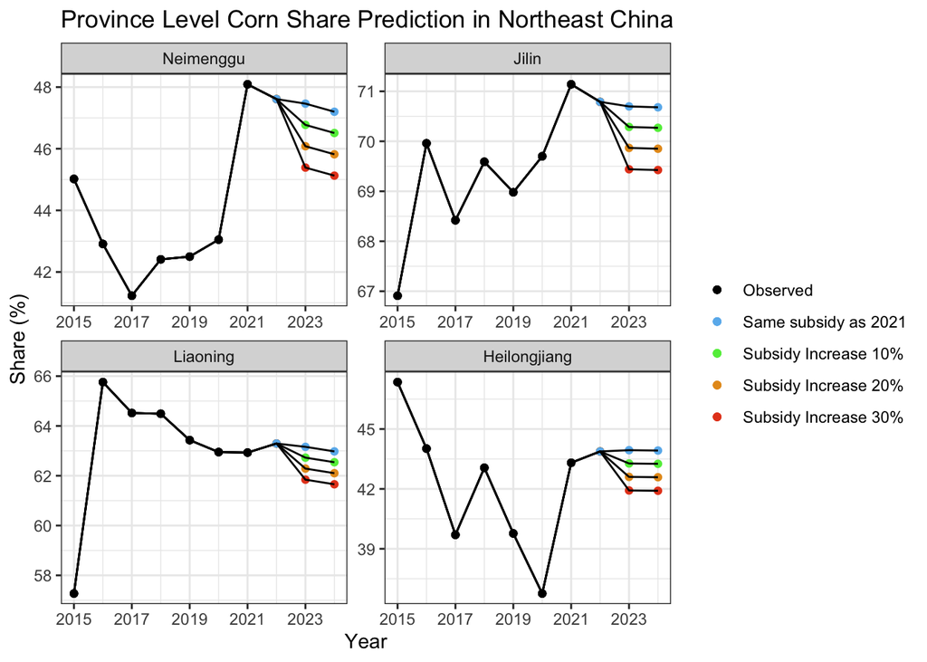

```r
ggplot() +
  geom_point(aes(x = year, y = share, color = interaction(crop, pred, sep = "_")),
             data = share_new01 %>% filter(crop == "corn", year >= 2015)) +
  geom_point(aes(x = year, y = share, color = interaction(crop, pred, sep = "_")),
             data = share_new02 %>% filter(crop == "corn", year >= 2015)) +
  geom_point(aes(x = year, y = share, color = interaction(crop, pred, sep = "_")),
             data = share_new03 %>% filter(crop == "corn", year >= 2015)) +
  geom_point(aes(x = year, y = share, color = interaction(crop, pred, sep = "_")),
             data = share_newsame %>% filter(crop == "corn", year >= 2015)) +
  geom_line(aes(x = year, y = share),
            data = share_newsame %>% filter(crop == "corn", year >= 2015)) +
  geom_line(aes(x = year, y = share),
            data = share_new01 %>% filter(crop == "corn", year >= 2015)) +
  geom_line(aes(x = year, y = share),
            data = share_new02 %>% filter(crop == "corn", year >= 2015)) +
  geom_line(aes(x = year, y = share),
            data = share_new03 %>% filter(crop == "corn", year >= 2015)) +
  facet_wrap(~region, nrow = 2, scales = "free") +
    scale_x_continuous(breaks = seq(2015, 2024, 2)) +
  scale_color_manual(name = "",
                     values = c("corn_FALSE" = "black",
                                "corn_TRUE" = "#6AB8EE",
                                "corn_T01" = "#5FEC49",
                                "corn_T02" = "#E69A1F",
                                "corn_T03" = "#E6471F"),
                     labels = c("Observed", "Same subsidy as 2021",
                                "Subsidy Increase 10%", "Subsidy Increase 20%",
                                "Subsidy Increase 30%")) +
  xlab("Year") + ylab("Share (%)") +
  ggtitle("Province Level Corn Share Prediction in Northeast China") +
  theme(plot.title = element_text(hjust = 0.5)) +
  theme_bw()
```

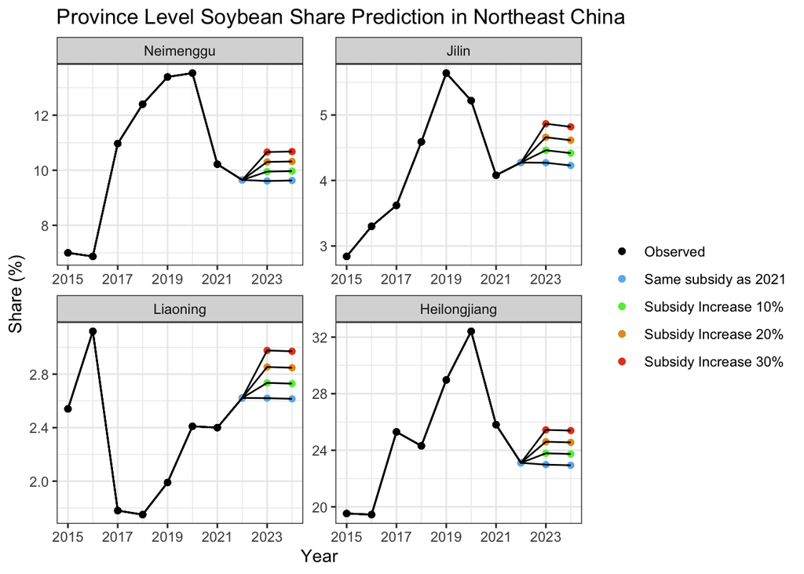

```r
ggplot() +
  geom_point(aes(x = year, y = share, color = interaction(crop, pred, sep = "_")),
             data = share_new01 %>% filter(crop == "soybean", year >= 2015)) +
  geom_point(aes(x = year, y = share, color = interaction(crop, pred, sep = "_")),
             data = share_new02 %>% filter(crop == "soybean", year >= 2015)) +
  geom_point(aes(x = year, y = share, color = interaction(crop, pred, sep = "_")),
             data = share_new03 %>% filter(crop == "soybean", year >= 2015)) +
  geom_point(aes(x = year, y = share, color = interaction(crop, pred, sep = "_")),
             data = share_newsame %>% filter(crop == "soybean", year >= 2015)) +
  geom_line(aes(x = year, y = share),
            data = share_newsame %>% filter(crop == "soybean", year >= 2015)) +
  geom_line(aes(x = year, y = share),
            data = share_new01 %>% filter(crop == "soybean", year >= 2015)) +
  geom_line(aes(x = year, y = share),
            data = share_new02 %>% filter(crop == "soybean", year >= 2015)) +
  geom_line(aes(x = year, y = share),
            data = share_new03 %>% filter(crop == "soybean", year >= 2015)) +
  facet_wrap(~region, nrow = 2, scales = "free") +
  scale_x_continuous(breaks = seq(2015, 2024, 2)) +
  scale_color_manual(name = "",
                     values = c("soybean_FALSE" = "black",
                                "soybean_TRUE" = "#6AB8EE",
                                "soybean_T01" = "#5FEC49",
                                "soybean_T02" = "#E69A1F",
                                "soybean_T03" = "#E6471F"),
                     labels = c("Observed", "Same subsidy as 2021",
                                "Subsidy Increase 10%", "Subsidy Increase 20%",
                                "Subsidy Increase 30%")) +
  xlab("Year") + ylab("Share (%)") +
  ggtitle("Province Level Soybean Share Prediction in Northeast China") +
  theme(plot.title = element_text(hjust = 0.5)) +
  theme_bw()
```

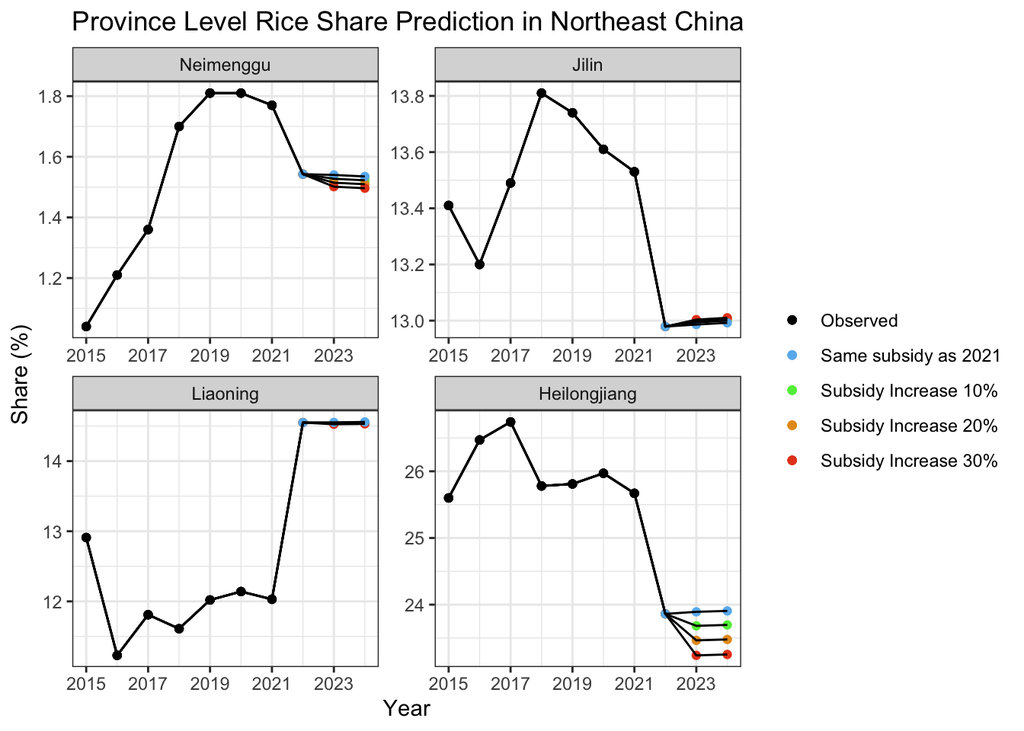

```r
ggplot() +
  geom_point(aes(x = year, y = share, color = interaction(crop, pred, sep = "_")),
             data = share_new01 %>% filter(crop == "rice", year >= 2015)) +
  geom_point(aes(x = year, y = share, color = interaction(crop, pred, sep = "_")),
             data = share_new02 %>% filter(crop == "rice", year >= 2015)) +
  geom_point(aes(x = year, y = share, color = interaction(crop, pred, sep = "_")),
             data = share_new03 %>% filter(crop == "rice", year >= 2015)) +
  geom_point(aes(x = year, y = share, color = interaction(crop, pred, sep = "_")),
             data = share_newsame %>% filter(crop == "rice", year >= 2015)) +
  geom_line(aes(x = year, y = share),
            data = share_newsame %>% filter(crop == "rice", year >= 2015)) +
  geom_line(aes(x = year, y = share),
            data = share_new01 %>% filter(crop == "rice", year >= 2015)) +
  geom_line(aes(x = year, y = share),
            data = share_new02 %>% filter(crop == "rice", year >= 2015)) +
  geom_line(aes(x = year, y = share),
            data = share_new03 %>% filter(crop == "rice", year >= 2015)) +
  facet_wrap(~region, nrow = 2, scales = "free") +
  scale_x_continuous(breaks = seq(2015, 2024, 2)) +
  scale_color_manual(name = "",
                     values = c("rice_FALSE" = "black",
                                "rice_TRUE" = "#6AB8EE",
                                "rice_T01" = "#5FEC49",
                                "rice_T02" = "#E69A1F",
                                "rice_T03" = "#E6471F"),
                     labels = c("Observed", "Same subsidy as 2021",
                                "Subsidy Increase 10%", "Subsidy Increase 20%",
                                "Subsidy Increase 30%")) +
  xlab("Year") + ylab("Share (%)") +
  ggtitle("Province Level Rice Share Prediction in Northeast China") +
  theme(plot.title = element_text(hjust = 0.5)) +
  theme_bw()
```

### Acreage Prediction

```r
acre_newsame <-
  regdat_V2 %>% left_join(., acredat) %>% mutate(acre = share * total/100) %>%
  select(region, crop, year, acre) %>%
  mutate(acre_LB = acre, acre_UB = acre) %>%
  rbind(., preddat_newsame %>% select(region, crop, year, acre, acre_LB, acre_UB)) %>%
  arrange(region, crop, year) %>%
  filter(crop %in% c("corn", "rice", "soybean")) %>%
  mutate(pred = rep(rep(c(F, T), c(21, 3)), 12))
acre_new01 <-
  regdat_V2 %>% left_join(., acredat) %>% mutate(acre = share * total/100) %>%
  select(region, crop, year, acre) %>%
  mutate(acre_LB = acre, acre_UB = acre) %>%
  rbind(., preddat_new01 %>% select(region, crop, year, acre, acre_LB, acre_UB)) %>%
  arrange(region, crop, year) %>%
  filter(crop %in% c("corn", "rice", "soybean")) %>%
  mutate(pred = rep(rep(c(F, "T01"), c(21, 3)), 12))
acre_new02 <-
  regdat_V2 %>% left_join(., acredat) %>% mutate(acre = share * total/100) %>%
  select(region, crop, year, acre) %>%
  mutate(acre_LB = acre, acre_UB = acre) %>%
  rbind(., preddat_new02 %>% select(region, crop, year, acre, acre_LB, acre_UB)) %>%
  arrange(region, crop, year) %>%
  filter(crop %in% c("corn", "rice", "soybean")) %>%
  mutate(pred = rep(rep(c(F, "T02"), c(21, 3)), 12))
acre_new03 <-
  regdat_V2 %>% left_join(., acredat) %>% mutate(acre = share * total/100) %>%
  select(region, crop, year, acre) %>%
  mutate(acre_LB = acre, acre_UB = acre) %>%
  rbind(., preddat_new03 %>% select(region, crop, year, acre, acre_LB, acre_UB)) %>%
  arrange(region, crop, year) %>%
  filter(crop %in% c("corn", "rice", "soybean")) %>%
  mutate(pred = rep(rep(c(F, "T03"), c(21, 3)), 12))
```

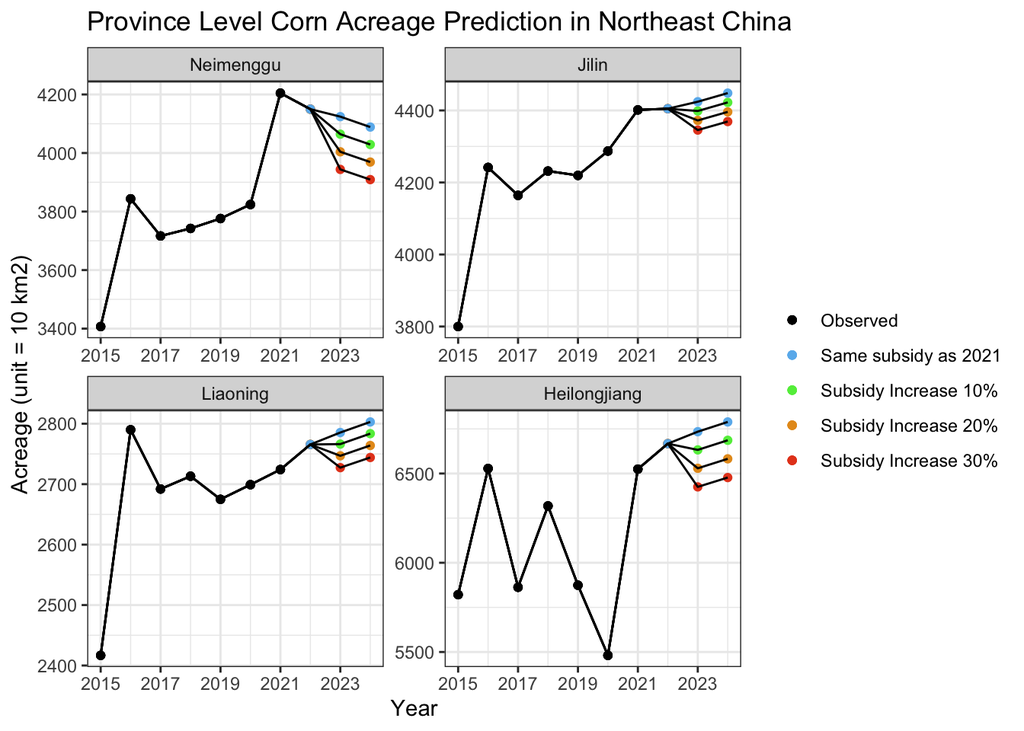

```r
ggplot() +
  geom_point(aes(x = year, y = acre, color = interaction(crop, pred, sep = "_")),
             data = acre_new01 %>% filter(crop == "corn", year >= 2015)) +
  geom_point(aes(x = year, y = acre, color = interaction(crop, pred, sep = "_")),
             data = acre_new02 %>% filter(crop == "corn", year >= 2015)) +
  geom_point(aes(x = year, y = acre, color = interaction(crop, pred, sep = "_")),
             data = acre_new03 %>% filter(crop == "corn", year >= 2015)) +
  geom_point(aes(x = year, y = acre, color = interaction(crop, pred, sep = "_")),
             data = acre_newsame %>% filter(crop == "corn", year >= 2015)) +
  geom_line(aes(x = year, y = acre),
            data = acre_newsame %>% filter(crop == "corn", year >= 2015)) +
  geom_line(aes(x = year, y = acre),
            data = acre_new01 %>% filter(crop == "corn", year >= 2015)) +
  geom_line(aes(x = year, y = acre),
            data = acre_new02 %>% filter(crop == "corn", year >= 2015)) +
  geom_line(aes(x = year, y = acre),
            data = acre_new03 %>% filter(crop == "corn", year >= 2015)) +
  facet_wrap(~region, nrow = 2, scales = "free") +
    scale_x_continuous(breaks = seq(2015, 2024, 2)) +
  scale_color_manual(name = "",
                     values = c("corn_FALSE" = "black",
                                "corn_TRUE" = "#6AB8EE",
                                "corn_T01" = "#5FEC49",
                                "corn_T02" = "#E69A1F",
                                "corn_T03" = "#E6471F"),
                     labels = c("Observed", "Same subsidy as 2021",
                                "Subsidy Increase 10%", "Subsidy Increase 20%",
                                "Subsidy Increase 30%")) +
  xlab("Year") + ylab("Acreage (unit = 10 km2)") +
  ggtitle("Province Level Corn Acreage Prediction in Northeast China") +
  theme(plot.title = element_text(hjust = 0.5)) +
  theme_bw()
```

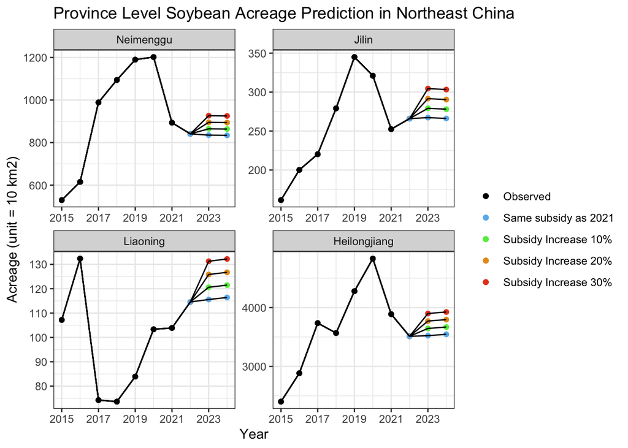

```r
ggplot() +
  geom_point(aes(x = year, y = acre, color = interaction(crop, pred, sep = "_")),
             data = acre_new01 %>% filter(crop == "soybean", year >= 2015)) +
  geom_point(aes(x = year, y = acre, color = interaction(crop, pred, sep = "_")),
             data = acre_new02 %>% filter(crop == "soybean", year >= 2015)) +
  geom_point(aes(x = year, y = acre, color = interaction(crop, pred, sep = "_")),
             data = acre_new03 %>% filter(crop == "soybean", year >= 2015)) +
  geom_point(aes(x = year, y = acre, color = interaction(crop, pred, sep = "_")),
             data = acre_newsame %>% filter(crop == "soybean", year >= 2015)) +
  geom_line(aes(x = year, y = acre),
            data = acre_newsame %>% filter(crop == "soybean", year >= 2015)) +
  geom_line(aes(x = year, y = acre),
            data = acre_new01 %>% filter(crop == "soybean", year >= 2015)) +
  geom_line(aes(x = year, y = acre),
            data = acre_new02 %>% filter(crop == "soybean", year >= 2015)) +
  geom_line(aes(x = year, y = acre),
            data = acre_new03 %>% filter(crop == "soybean", year >= 2015)) +
  facet_wrap(~region, nrow = 2, scales = "free") +
  scale_x_continuous(breaks = seq(2015, 2024, 2)) +
  scale_color_manual(name = "",
                     values = c("soybean_FALSE" = "black",
                                "soybean_TRUE" = "#6AB8EE",
                                "soybean_T01" = "#5FEC49",
                                "soybean_T02" = "#E69A1F",
                                "soybean_T03" = "#E6471F"),
                     labels = c("Observed", "Same subsidy as 2021",
                                "Subsidy Increase 10%", "Subsidy Increase 20%",
                                "Subsidy Increase 30%")) +
  xlab("Year") + ylab("Acreage (unit = 10 km2)") +
  ggtitle("Province Level Soybean Acreage Prediction in Northeast China") +
  theme(plot.title = element_text(hjust = 0.5)) +
  theme_bw()
```

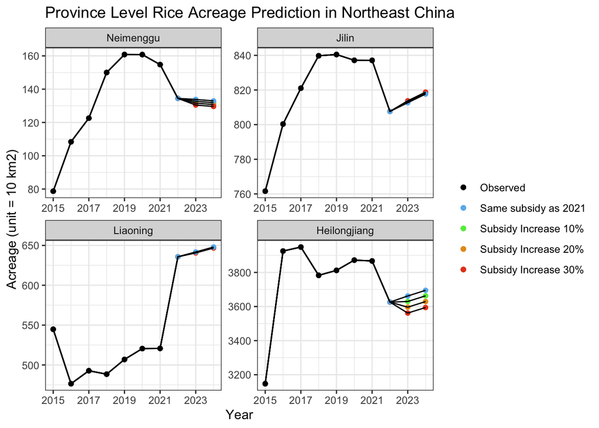

```r
ggplot() +
  geom_point(aes(x = year, y = acre, color = interaction(crop, pred, sep = "_")),
             data = acre_new01 %>% filter(crop == "rice", year >= 2015)) +
  geom_point(aes(x = year, y = acre, color = interaction(crop, pred, sep = "_")),
             data = acre_new02 %>% filter(crop == "rice", year >= 2015)) +
  geom_point(aes(x = year, y = acre, color = interaction(crop, pred, sep = "_")),
             data = acre_new03 %>% filter(crop == "rice", year >= 2015)) +
  geom_point(aes(x = year, y = acre, color = interaction(crop, pred, sep = "_")),
             data = acre_newsame %>% filter(crop == "rice", year >= 2015)) +
  geom_line(aes(x = year, y = acre),
            data = acre_newsame %>% filter(crop == "rice", year >= 2015)) +
  geom_line(aes(x = year, y = acre),
            data = acre_new01 %>% filter(crop == "rice", year >= 2015)) +
  geom_line(aes(x = year, y = acre),
            data = acre_new02 %>% filter(crop == "rice", year >= 2015)) +
  geom_line(aes(x = year, y = acre),
            data = acre_new03 %>% filter(crop == "rice", year >= 2015)) +
  facet_wrap(~region, nrow = 2, scales = "free") +
    scale_x_continuous(breaks = seq(2015, 2024, 2)) +
  scale_color_manual(name = "",
                     values = c("rice_FALSE" = "black",
                                "rice_TRUE" = "#6AB8EE",
                                "rice_T01" = "#5FEC49",
                                "rice_T02" = "#E69A1F",
                                "rice_T03" = "#E6471F"),
                     labels = c("Observed", "Same subsidy as 2021",
                                "Subsidy Increase 10%", "Subsidy Increase 20%",
                                "Subsidy Increase 30%")) +
  xlab("Year") + ylab("Acreage (unit = 10 km2)") +
  ggtitle("Province Level Rice Acreage Prediction in Northeast China") +
  theme(plot.title = element_text(hjust = 0.5)) +
  theme_bw()
```

### Backup Share Data {-}

Share Prediction

```r
DT::datatable(
  data.frame(share_newsame %>% filter(year > 2021) %>% select(-pred, -share),
           same = share_newsame %>% filter(year > 2021) %>% "$"(share) %>% round(2),
           increase10 = share_new01 %>% filter(year > 2021) %>% "$"(share) %>% round(2),
           increase20 = share_new02 %>% filter(year > 2021) %>% "$"(share) %>% round(2),
           increase30 = share_new03 %>% filter(year > 2021) %>% "$"(share) %>% round(2)),
  options = list(pageLength = 9)
)
```

|  | region | crop | year | same | increase10 | increase20 | increase30 |
| --- | --- | --- | --- | --- | --- | --- | --- |
| 1 | Neimenggu | corn | 2022 | 47.61 | 47.61 | 47.61 | 47.61 |
| 2 | Neimenggu | corn | 2023 | 47.46 | 46.77 | 46.08 | 45.39 |
| 3 | Neimenggu | corn | 2024 | 47.2 | 46.51 | 45.82 | 45.13 |
| 4 | Neimenggu | rice | 2022 | 1.54 | 1.54 | 1.54 | 1.54 |
| 5 | Neimenggu | rice | 2023 | 1.54 | 1.53 | 1.51 | 1.5 |
| 6 | Neimenggu | rice | 2024 | 1.54 | 1.52 | 1.51 | 1.5 |
| 7 | Neimenggu | soybean | 2022 | 9.65 | 9.65 | 9.65 | 9.65 |
| 8 | Neimenggu | soybean | 2023 | 9.61 | 9.95 | 10.3 | 10.66 |
| 9 | Neimenggu | soybean | 2024 | 9.63 | 9.97 | 10.32 | 10.68 |
| 10 | Jilin | corn | 2022 | 70.79 | 70.79 | 70.79 | 70.79 |

[output cut: 26 more lines]

Acreage Prediction

```r
DT::datatable(
  data.frame(acre_newsame %>% filter(year > 2021) %>% select(region, crop, year),
           same = acre_newsame %>% filter(year > 2021) %>% "$"(acre) %>% round(2),
           increase10 = acre_new01 %>% filter(year > 2021) %>% "$"(acre) %>% round(2),
           increase20 = acre_new02 %>% filter(year > 2021) %>% "$"(acre) %>% round(2),
           increase30 = acre_new03 %>% filter(year > 2021) %>% "$"(acre) %>% round(2)),
  options = list(pageLength = 9)
)
```

|  | region | crop | year | same | increase10 | increase20 | increase30 |
| --- | --- | --- | --- | --- | --- | --- | --- |
| 1 | Neimenggu | corn | 2022 | 4149.86 | 4149.86 | 4149.86 | 4149.86 |
| 2 | Neimenggu | corn | 2023 | 4124.29 | 4064.32 | 4004.2 | 3943.96 |
| 3 | Neimenggu | corn | 2024 | 4088.69 | 4028.97 | 3969.11 | 3909.13 |
| 4 | Neimenggu | rice | 2022 | 134.47 | 134.47 | 134.47 | 134.47 |
| 5 | Neimenggu | rice | 2023 | 133.82 | 132.73 | 131.61 | 130.46 |
| 6 | Neimenggu | rice | 2024 | 132.98 | 131.88 | 130.76 | 129.61 |
| 7 | Neimenggu | soybean | 2022 | 840.98 | 840.98 | 840.98 | 840.98 |
| 8 | Neimenggu | soybean | 2023 | 835.13 | 864.77 | 895.24 | 926.55 |
| 9 | Neimenggu | soybean | 2024 | 834.02 | 863.57 | 893.94 | 925.13 |
| 10 | Jilin | corn | 2022 | 4404.84 | 4404.84 | 4404.84 | 4404.84 |

[output cut: 26 more lines]